$$ \DeclareMathOperator{\cor}{cor} \DeclareMathOperator{\cov}{cov} \DeclareMathOperator{\sd}{sd} \DeclareMathOperator{\se}{se} \DeclareMathOperator{\diag}{diag} \DeclareMathOperator{\quantile}{quantile} \DeclareMathOperator{\logit}{logit} $$

# POLS/CSSS 503: Problem Set 2 Solutions

Jeffrey B. Arnold

April 24, 2015

Source the libraries that will be used

```r
library("ggplot2")
library("dplyr")
library("tidyr")
library("broom")
```

## Problem 1

I’ll use the **httr** file to download the `csv` file directly.

```r
sprinters_url <- "http://uw-pols503.github.io/pols_503_sp15/data/sprinters.csv"
sprinters <- read.csv(sprinters_url, stringsAsFactors = FALSE)
```

**a.** Create a matrix from the sprinters data using `as.matrix`, selecting only the `year` and `women` columns. Then append a column of 1s using `cbind`.

```r
X <- cbind(1, as.matrix(select(sprinters, year, women)))
head(X)
```

```
##        year women
## [1,] 1 1900     0
## [2,] 1 1904     0
## [3,] 1 1908     0
## [4,] 1 1912     0
## [5,] 1 1920     0
## [6,] 1 1924     0
```

Now, calculate $(X' X)^{-1} X' y$.

```r
solve(t(X) %*% X) %*% t(X) %*% sprinters$finish
```

```
##              [,1]
##       34.96003685
## year  -0.01260896
## women  1.09281183
```

**b.** Run a regression of finish time on year and whether the race was women.

```r
lm_finish <- lm(finish ~ year + women, data = sprinters)
lm_finish
```

```
##
## Call:
## lm(formula = finish ~ year + women, data = sprinters)
##
## Coefficients:
## (Intercept)         year        women
##    34.96004     -0.01261      1.09281
```

**c.** One way to do this re-using the fitted values is with the **broom** package function `augment`, which returns the original data, augmented with fitted values and other quantities calculated from the regression.

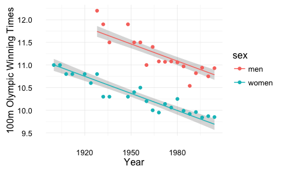

```r
x_axis_scale <- scale_x_continuous("Year")
y_axis_scale <- scale_y_continuous("100m Olympic Winning Times")

sprinters <- sprinters %>%
  mutate(sex = plyr::mapvalues(women, c(0, 1), c("women", "men")))

ggplot(augment(lm_finish) %>%
       mutate(sex = plyr::mapvalues(women, c(0, 1), c("women", "men"))),
       aes(x = year, group = sex,
           colour = sex)) +
  geom_ribbon(alpha = 0.2, colour = NA,
              mapping = aes(ymin = .fitted - 2 * .se.fit,
                            ymax = .fitted + 2 * .se.fit)) +
  geom_point(mapping = aes(y = finish)) +
  geom_line(mapping = aes(y = .fitted)) +
  x_axis_scale + y_axis_scale +
  theme_minimal()
```

This is a more manual way of creating the plot

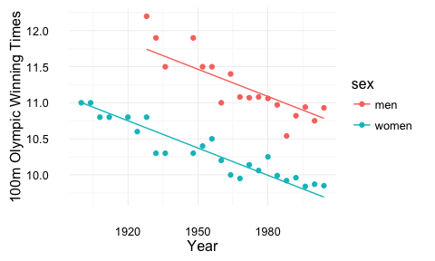

```r
ggplot(sprinters %>% mutate(fitted = fitted(lm_finish)),
       aes(x = year, group = sex,
           colour = sex)) +
  geom_point(mapping = aes(y = finish)) +
  geom_line(mapping = aes(y = fitted)) +
  x_axis_scale + y_axis_scale +
  theme_minimal()
```

**d.** Run a regression of finish on year, women, and an interaction between year and women. This is almost equivalent to running separate regressions of finish time on year for men and women.

```r
lm_finish_interact <- lm(finish ~ year * women, data = sprinters)
```

**e.** Redo the plot with a new fit, one for each level of `women`. This can also be done with the **broom** package `tidy`.

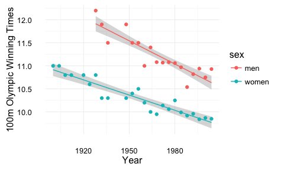

```r
ggplot(augment(lm_finish_interact) %>%
       mutate(sex = plyr::mapvalues(women, c(0, 1), c("women", "men"))),
       aes(x = year, group = sex,
           colour = sex)) +
  geom_ribbon(alpha = 0.2, colour = NA,
              mapping = aes(ymin = .fitted - 2 * .se.fit,
                            ymax = .fitted + 2 * .se.fit)) +
  geom_point(mapping = aes(y = finish)) +
  geom_line(mapping = aes(y = .fitted)) +
  x_axis_scale + y_axis_scale +
  theme_minimal()
```

The **ggplot2** function `geom_smooth` does something similar, but not exactly what we want. That function will run **separate** regressions for each group. Which means that there will be different estimates of the regression standard error for each group. When regressions are run with full interactions for each group it is almost the same as running separate regression, except that it imposes the assumption of homogeneous variance.

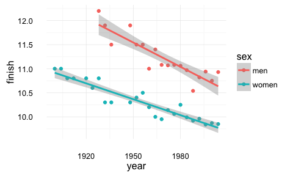

```r
ggplot(sprinters, aes(x = year, y = finish, colour = sex)) +
  geom_point() +
  geom_smooth(method = "lm") +
  theme_minimal()
```

Although the point estimates are effectively the same, the values of `Residual standard error` are slightly different.

```r
summary(lm(finish ~ year, data = filter(sprinters, women == 1)))
```

```
##
## Call:
## lm(formula = finish ~ year, data = filter(sprinters, women ==
##     1))
##
## Residuals:
##      Min       1Q   Median       3Q      Max
## -0.37579 -0.08460  0.00929  0.08285  0.32234
##
## Coefficients:
##              Estimate Std. Error t value Pr(>|t|)
## (Intercept) 44.347049   4.284251   10.35 1.70e-08 ***
## year        -0.016822   0.002176   -7.73 8.63e-07 ***
## ---
## Signif. codes:  0 '***' 0.001 '**' 0.01 '*' 0.05 '.' 0.1 ' ' 1
##
## Residual standard error: 0.2104 on 16 degrees of freedom
## Multiple R-squared:  0.7888, Adjusted R-squared:  0.7756
## F-statistic: 59.76 on 1 and 16 DF,  p-value: 8.626e-07
```

```r
summary(lm(finish ~ year, data = filter(sprinters, women == 0)))
```

```
##
## Call:
## lm(formula = finish ~ year, data = filter(sprinters, women ==
##     0))
##
## Residuals:
##       Min        1Q    Median        3Q       Max
## -0.263708 -0.052702  0.007381  0.080048  0.214559
##
## Coefficients:
##               Estimate Std. Error t value Pr(>|t|)
## (Intercept) 31.8264525  1.6796428   18.95 4.11e-15 ***
## year        -0.0110056  0.0008593  -12.81 1.13e-11 ***
## ---
## Signif. codes:  0 '***' 0.001 '**' 0.01 '*' 0.05 '.' 0.1 ' ' 1
##
## Residual standard error: 0.1347 on 22 degrees of freedom
## Multiple R-squared:  0.8817, Adjusted R-squared:  0.8764
## F-statistic:   164 on 1 and 22 DF,  p-value: 1.128e-11
```

**f.** Calculate the predicted winning times of the 100 m sprints in 2001.

```r
sprinters_2001 <- data_frame(year = rep(2001, 2),
                             women = c(0, 1))
predict(lm_finish_interact, newdata = sprinters_2001)
```

```
##         1         2
##  9.804324 10.686086
```

Although there was no Olympics in 2001, there was a World Championship, which Maurice Greene won in 9.82 and Zhanna Pintusevich won in 10.82.

```r
sprinters_2156 <- data_frame(year = rep(2156, 2),
                             women = c(0, 1))
predict(lm_finish_interact, newdata = sprinters_2156,
       interval = "prediction")
```

```
##        fit      lwr      upr
## 1 8.098462 7.530861 8.666063
## 2 8.078666 7.320762 8.836569
```

The point predictions of the women’s winning time is less than that of the men’s winning time.

**h.** No. This is far outside the range of data used to estimate the regression (1900 to 2004). It is also logically inconsistent, as in 3000, it would predict the winning time to be negative.

```r
sprinters_3000 <- data_frame(year = rep(3000, 2),
                             women = c(0, 1))
predict(lm_finish_interact, newdata = sprinters_3000,
       interval = "prediction")
```

```
##         fit       lwr       upr
## 1 -1.190232 -3.522689  1.142225
## 2 -6.119162 -9.822388 -2.415935
```

Let’s visualize this. The `expand.grid` function is an easy way to create combinations of variables.

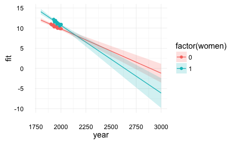

```r
sprinters_to_3000 <- expand.grid(year = seq(1800, 3000, by = 10),
                                 women = c(0, 1))
sprinters_to_3000_pred <-
  cbind(sprinters_to_3000,
        predict(lm_finish_interact, newdata = sprinters_to_3000,
                interval = "prediction"))

ggplot() +
  geom_line(data = sprinters_to_3000_pred, aes(x = year, y = fit,
                                              colour = factor(women))) +
  geom_ribbon(data = sprinters_to_3000_pred,
              aes(x = year,
                  ymin = lwr,
                  ymax = upr,
                  fill = factor(women)), alpha = 0.2) +
  geom_point(data = sprinters, aes(x = year, y = finish,
                                   colour = factor(women))) +
  theme_minimal()
```

## Problem 2

Let’s create this data:

```r
data("anscombe")
anscombe2 <- anscombe %>%
  mutate(obs = row_number()) %>%
  gather(variable_dataset, value, - obs) %>%
  separate(variable_dataset, c("variable", "dataset"), sep = 1L) %>%
  spread(variable, value) %>%
  arrange(dataset, obs)
```

**a.** All four datasets have similar summary statistics for x, y and the linear relationship between x and y.

The mean and standard deviation of $x$

```r
anscombe2 %>%
  group_by(dataset) %>%
  summarise(mean_x = mean(x),
            mean_y = mean(y),
            sd_x = sd(x),
            sd_y = sd(y),
            cor_xy = cor(x, y))
```

```
## Source: local data frame [4 x 6]
##
##   dataset mean_x   mean_y     sd_x     sd_y    cor_xy
##     (chr)  (dbl)    (dbl)    (dbl)    (dbl)     (dbl)
## 1       1      9 7.500909 3.316625 2.031568 0.8164205
## 2       2      9 7.500909 3.316625 2.031657 0.8162365
## 3       3      9 7.500000 3.316625 2.030424 0.8162867
## 4       4      9 7.500909 3.316625 2.030579 0.8165214
```

The regressions could be run separately

```r
lm(y ~ x, data = filter(anscombe2, dataset == 1))
```

```
##
## Call:
## lm(formula = y ~ x, data = filter(anscombe2, dataset == 1))
##
## Coefficients:
## (Intercept)            x
##      3.0001       0.5001
```

```r
# ...
```

but, that isn’t fun.

You could do it in a `for` loop

```r
for (i in unique(anscombe2$dataset)) {
  cat("\n")
  cat(paste("Dataset = ", i, "\n", sep = ""))
  print(lm(y ~ x, data = filter(anscombe2, dataset == i)))
}
```

```
##
## Dataset = 1
##
## Call:
## lm(formula = y ~ x, data = filter(anscombe2, dataset == i))
##
## Coefficients:
## (Intercept)            x
##      3.0001       0.5001
##
##
## Dataset = 2
##
## Call:
## lm(formula = y ~ x, data = filter(anscombe2, dataset == i))
##
## Coefficients:
## (Intercept)            x
##       3.001        0.500
##
##
## Dataset = 3
##
## Call:
## lm(formula = y ~ x, data = filter(anscombe2, dataset == i))
##
## Coefficients:
## (Intercept)            x
##      3.0025       0.4997
##
##
## Dataset = 4
##
## Call:
## lm(formula = y ~ x, data = filter(anscombe2, dataset == i))
##
## Coefficients:
## (Intercept)            x
##      3.0017       0.4999
```

Note, that by default, R functions usually print objects if they are not assigned to a variable. However, within a `for` loop, you need to explicitly print objects with the `print` function.

Instead, let’s take full advantage of dplyr, tidy, and broom. Here are a couple of ways of running this code:

```r
anscombe2 %>%
  group_by(dataset) %>%
  do(mod = lm(y ~ x, data = .)) %>%
  mutate(intercept = coef(mod)[1],
         slope = coef(mod)[2])
```

```
## Source: local data frame [4 x 4]
## Groups: <by row>
##
##   dataset     mod intercept     slope
##     (chr)   (chr)     (dbl)     (dbl)
## 1       1 <S3:lm>  3.000091 0.5000909
## 2       2 <S3:lm>  3.000909 0.5000000
## 3       3 <S3:lm>  3.002455 0.4997273
## 4       4 <S3:lm>  3.001727 0.4999091
```

```r
anscombe2 %>%
  group_by(dataset) %>%
  do(select(tidy(lm(y ~ x, data = .)), term, estimate)) %>%
  spread(term, estimate)
```

```
## Source: local data frame [4 x 3]
## Groups: dataset [4]
##
##   dataset (Intercept)         x
##     (chr)       (dbl)     (dbl)
## 1       1    3.000091 0.5000909
## 2       2    3.000909 0.5000000
## 3       3    3.002455 0.4997273
## 4       4    3.001727 0.4999091
```

**b** Plot each dataset. They look very different, even though their coefficients are similar

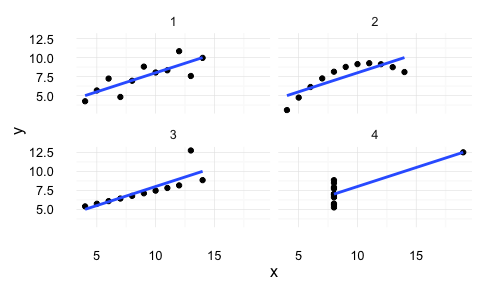

```r
ggplot(anscombe2, aes(x = x, y = y)) +
  geom_point() +
  geom_smooth(method = "lm", se = FALSE) +
  facet_wrap(~ dataset, nrow = 2) +
  theme_minimal()
```

## Problem 3

There will be many different responses.